# Proiect P&S - Analiza set date esoph

Cherim Erol, Roman Robert, Martinas Paul

28/1/2022

## Descrierea setului de date

Proiectul trateaza partea teoretica si practica (grafice/tabele) a unei probleme de interes public pe baza setului de date “esoph” din R.

Scopul proiectului este stabilirea conexiunii intre rata cancerului esofagial si 3 variabile:

- Varsta
- Consum de alcool
- Consum de tutun

Setul de date “esoph” este alcatuit din 88 de intrari, impartite dupa urmatoarele criterii:

- Categorie de varsta (ani): 25-34, 35-44, 45-54, 55-64, 65-74, 75+
- Consum de tutun (g/zi): 0-9, 10-19, 20-29, 30+
- Consum de alcool (g/zi): 0-39, 40-79, 80-119, 120+

Fiecare combinatie unica dintre cele 3 variabile vine insotita de numarul de cazuri de cancer si numarul de cazuri de control.

## Structura setului de date

Variabile control pentru fiecare coloana:

```r
summary(esoph)
```

```
##    agegp          alcgp         tobgp        ncases         ncontrols
##  25-34:15   0-39g/day:23   0-9g/day:24   Min.   : 0.000   Min.   : 1.00
##  35-44:15   40-79    :23   10-19   :24   1st Qu.: 0.000   1st Qu.: 3.00
##  45-54:16   80-119   :21   20-29   :20   Median : 1.000   Median : 6.00
##  55-64:16   120+     :21   30+     :20   Mean   : 2.273   Mean   :11.08
##  65-74:15                                3rd Qu.: 4.000   3rd Qu.:14.00
##  75+  :11                                Max.   :17.000   Max.   :60.00
```

[output not shown]

## Manipularea si analiza datelor

Pentru evidentierea celor mai expuse categorii de varsta trebuie realizata distributia procentajului de cazuri de cancer `ncases` normalizata in functie de suma numarului cazurilor de control pentru fiecare categorie `sum(ncontrols)`.

Din cauza naturii structurii setului, datele trebuie agregate in functie de categoria de varsta.

Obiectul `cases_by_age` reprezinta numarul total (`FUN=sum`) de cazuri de cancer `ncases` pentru fiecare cateogire de varsta, calculat cu functia `aggregate`.

```r
cases_by_age <- aggregate(esoph$ncases, by=list(agegp = esoph$agegp), FUN = sum)
cases_by_age
```

```
##   agegp  x
## 1 25-34  1
## 2 35-44  9
## 3 45-54 46
## 4 55-64 76
## 5 65-74 55
## 6   75+ 13
```

Obiectul `controls_by_age` reprezinta numarul total de control `ncotrols` pentru fiecare categorie de varsta. Se calculeaza de asemenea cu ajutorul functiei `aggregate`.

```r
controls_by_age <- aggregate(esoph$ncontrols, by=list(agegp = esoph$agegp), FUN = sum)
controls_by_age
```

```
##   agegp   x
## 1 25-34 116
## 2 35-44 199
## 3 45-54 213
## 4 55-64 242
## 5 65-74 161
## 6   75+  44
```

Vectorul `percentage_of_total` contine procentul de cazuri de cancer `ncases` din numarul de cazuri de control `ncontrols`.

```r
percentage_of_total <- cases_by_age$x * 100 / controls_by_age$x
```

### Distributia procentului cazurilor de cancer in functie de categoria de varsta

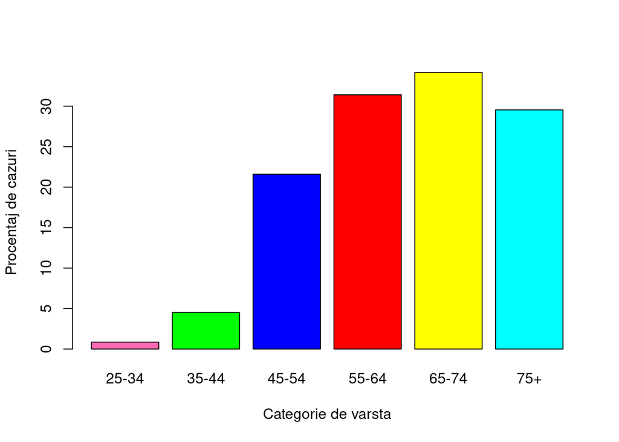

```r
vect_col <- c("hotpink", "green", "blue", "red", "yellow", "cyan")

barplot ( height = percentage_of_total,
          names.arg = cases_by_age$agegp,
          xlab = "Categorie de varsta",
          ylab = "Procentaj de cazuri",
          col = vect_col,
          )
```

Se observa cresterea cazurilor de cancer odata cu varsta, cele mai vulnerbaile categorii de varsta fiind 55-64, 65-74, 75+. Pentru observarea efectelor fiecarei substante, se realizeaza distributia consumului de alcool/tutun pentru fiecare categorie de varsta/categorie de consum.

Datele trebuie grupate in functie de categoria de varsta si consumul de tutun. Se genereaza subsetul `tob1` ce contine toate intrarile din setul de date ce se incadreaza in categoria de consum `"0-9g/day"`. Se pot observa primele 10 intrari pentru subsetul `tob1`.

```r
tob1 <- subset(esoph, subset = tobgp == "0-9g/day")
head(tob1,10)
```

```
##    agegp     alcgp    tobgp ncases ncontrols
## 1  25-34 0-39g/day 0-9g/day      0        40
## 5  25-34     40-79 0-9g/day      0        27
## 9  25-34    80-119 0-9g/day      0         2
## 12 25-34      120+ 0-9g/day      0         1
## 16 35-44 0-39g/day 0-9g/day      0        60
## 20 35-44     40-79 0-9g/day      0        35
## 24 35-44    80-119 0-9g/day      0        11
## 28 35-44      120+ 0-9g/day      2         3
## 31 45-54 0-39g/day 0-9g/day      1        46
## 35 45-54     40-79 0-9g/day      6        38
```

Obiectul `cases_by_age_tobacco1` reuneste variabilele `ncases`, `ncontrols`, grupate in functie de fiecare categorie de varsta. Se folosesc functiile `cbind` si `aggregate`.

```r
cases_by_age_tobacco1 <- aggregate(cbind(ncases=tob1$ncases, ncontrols= tob1$ncontrols), by=list(interv_varsta = tob1$agegp), FUN=sum)
cases_by_age_tobacco1
```

```
##   interv_varsta ncases ncontrols
## 1         25-34      0        70
## 2         35-44      2       109
## 3         45-54     14       104
## 4         55-64     25       117
## 5         65-74     31        99
## 6           75+      6        26
```

Se genereaza vectorul `proc_tob1` ce contine procentul de cazuri de cancer pentru fiecare categorie de varsta, pentru categoria de consum `"0-9g/day"`.

```r
proc_tob1 <- cases_by_age_tobacco1$ncases*100/cases_by_age_tobacco1$ncontrol
proc_tob1
```

```
## [1]  0.000000  1.834862 13.461538 21.367521 31.313131 23.076923
```

## Distributia procentajului cazurilor de cancer pentru consumatorii de tutun in fucntie de categoria de varsta

Se genereaza plotul ce evidentiaza procentul `proc_tob1` de cazuri de cancer raportat la categoria de varsta `agegp` pentru categoria de consum `"0-9g/day"`.

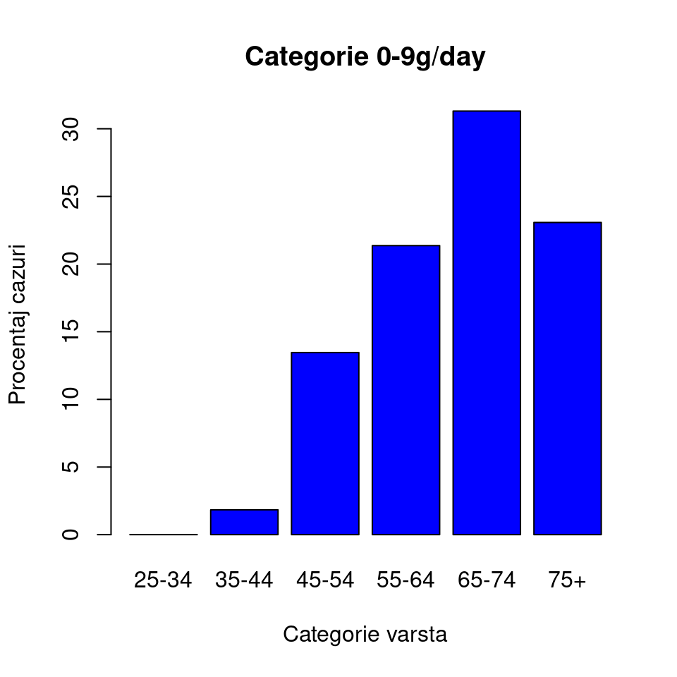

```r
barplot(proc_tob1,
        names.arg = cases_by_age$agegp,
        main = "Categorie 0-9g/day",
        xlab = "Categorie varsta",
        ylab = "Procentaj cazuri",
        col = "blue",
        beside=TRUE,
        )
```

Analog si pentru celelalte categorii de consum:

- 10-19g/day
- 20-29g/day
- 30+g/day

```r
tob2 <- subset(esoph, subset = tobgp == "10-19")
cases_by_age_tobacco2 <- aggregate(cbind(tob2$ncases, tob2$ncontrols), by=list(agegp = tob2$agegp), FUN=sum)
cases_by_age_tobacco2
```

```
##   agegp V1 V2
## 1 25-34  1 19
## 2 35-44  4 46
## 3 45-54 13 57
## 4 55-64 23 65
## 5 65-74 12 38
## 6   75+  5 11
```

```r
proctb2 <- cases_by_age_tobacco2$V1*100/cases_by_age_tobacco2$V2
proctb2
```

```
## [1]  5.263158  8.695652 22.807018 35.384615 31.578947 45.454545
```

```r
tob3 <- subset(esoph, subset = tobgp == "20-29")
cases_by_age_tobacco3 <- aggregate(cbind(tob3$ncases, tob3$ncontrols), by=list(agegp = tob3$agegp), FUN=sum)
cases_by_age_tobacco3
```

```
##   agegp V1 V2
## 1 25-34  0 11
## 2 35-44  3 27
## 3 45-54  8 33
## 4 55-64 12 38
## 5 65-74 10 20
## 6   75+  0  3
```

```r
proctb3 <- cases_by_age_tobacco3$V1*100/cases_by_age_tobacco3$V2
proctb3
```

```
## [1]  0.00000 11.11111 24.24242 31.57895 50.00000  0.00000
```

```r
tob4 <- subset(esoph, subset = tobgp == "30+")
cases_by_age_tobacco4 <- aggregate(cbind(tob4$ncases, tob4$ncontrols), by=list(agegp = tob4$agegp), FUN=sum)
cases_by_age_tobacco4
```

```
##   agegp V1 V2
## 1 25-34  0 16
## 2 35-44  0 17
## 3 45-54 11 19
## 4 55-64 16 22
## 5 65-74  2  4
## 6   75+  2  4
```

```r
proctb4 <- cases_by_age_tobacco4$V1*100/cases_by_age_tobacco4$V2
proctb4
```

```
## [1]  0.00000  0.00000 57.89474 72.72727 50.00000 50.00000
```

Si ploturile `barplot` aferente:

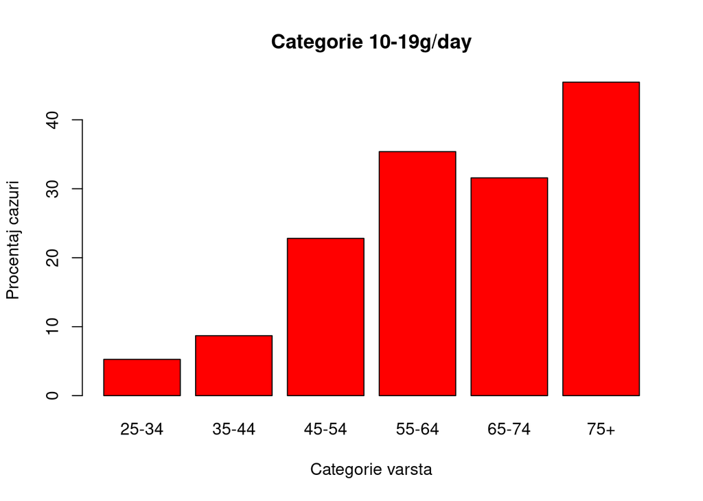

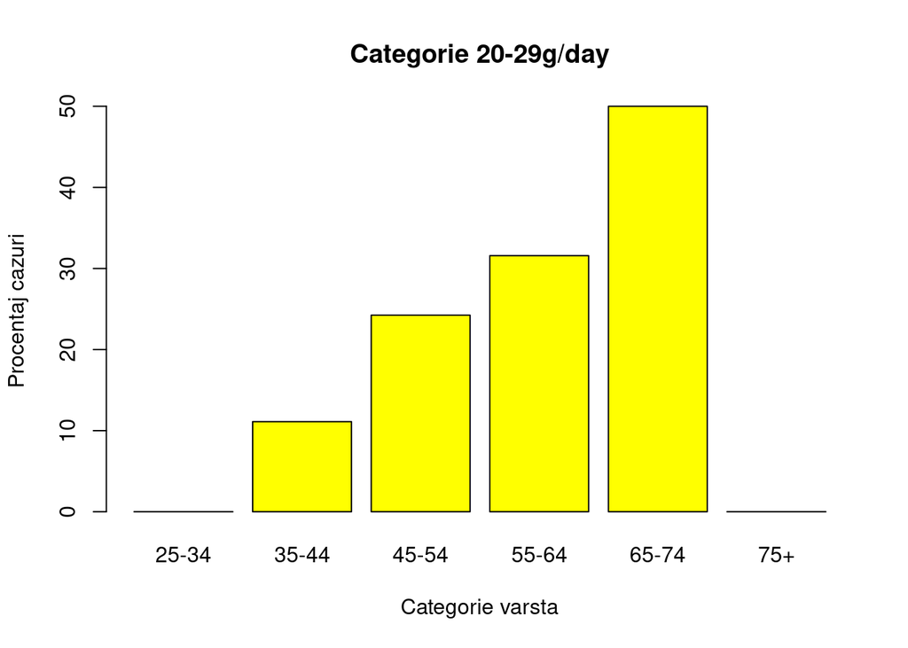

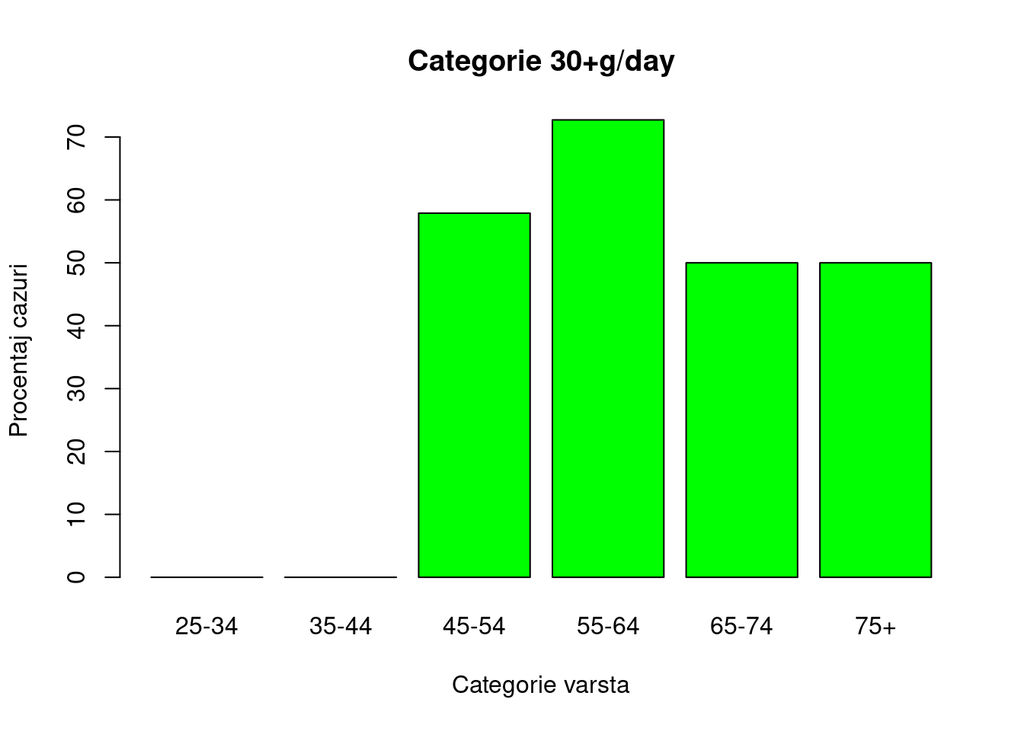

```r
barplot(proctb2,
        names.arg = cases_by_age$agegp,
        main = "Categorie 10-19g/day",
        xlab = "Categorie varsta",
        ylab = "Procentaj cazuri",
        col = "red",
        beside=TRUE,
        )
barplot(proctb3,
        names.arg = cases_by_age$agegp,
        main = "Categorie 20-29g/day",
        xlab = "Categorie varsta",
        ylab = "Procentaj cazuri",
        col = "yellow",
        beside=TRUE,
        )
barplot(proctb4,
        names.arg = cases_by_age$agegp,
        main = "Categorie 30+g/day",
        xlab = "Categorie varsta",
        ylab = "Procentaj cazuri",
        col = "green",
        beside=TRUE,
        )
```

Dupa cum se poate observa din graficul `"30+g/day"`, in categoriile tinere de varsta, respectiv `25-34` si `35-44` nu se depisteaza cazuri de cancer esofagian, de unde se poate observa o crestere a consumului de tutun odata cu varsta. (Categoriile predispuse la un consum mai mare de tutun sunt cele mai in varsta).

Pentru unificarea celor 4 grafice se foloseste functia `cbind`, in variabila `tob_t`.

```r
tob_t <- cbind("0-9"=proc_tob1, "10-19"=proctb2, "20-29"=proctb3, "30+"=proctb4)
tob_t
```

```
##            0-9     10-19    20-29      30+
## [1,]  0.000000  5.263158  0.00000  0.00000
## [2,]  1.834862  8.695652 11.11111  0.00000
## [3,] 13.461538 22.807018 24.24242 57.89474
## [4,] 21.367521 35.384615 31.57895 72.72727
## [5,] 31.313131 31.578947 50.00000 50.00000
## [6,] 23.076923 45.454545  0.00000 50.00000
```

Se realizeaza graficul pentru obiectul `tob_t`, ce reuneste toate categoriile de consum.

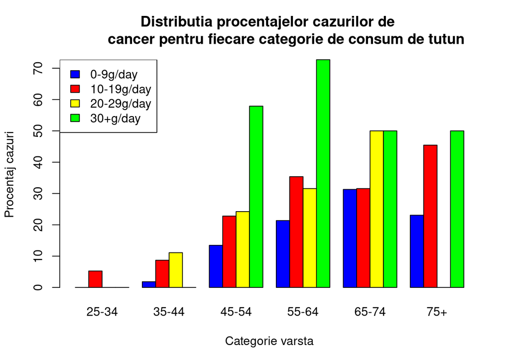

```r
vect_col4 <- c("blue", "red", "yellow", "green")
barplot(t(tob_t),
        main = "Distributia procentajelor cazurilor de
        cancer pentru fiecare categorie de consum de tutun",
        names.arg = cases_by_age$agegp,
        xlab = "Categorie varsta",
        ylab = "Procentaj cazuri",
        col = vect_col4,
        beside=TRUE,
        )
legend("topleft", legend=c("0-9g/day","10-19g/day","20-29g/day","30+g/day"), fill=vect_col4)
```

In graficul anterior, se pot observa urmatoarele:

- Riscul de cancer creste direct proportional cu varsta
- Riscul de cancer creste direct proportional cu cantitatea de tutun consumata
- Riscul de cancer se dubleaza pentru consumatorii de mai mult de 30 degrame de tutun pe zi

## Distributia procentului cazurilor de cancer pentru fiecare categorie de consum de alcool

Analog se genereaza un grafic si pentru categoriile de consum de alcool

```r
alc1 <- subset(esoph, subset = alcgp == "0-39g/day")
cases_by_age_alcohol1 <- aggregate(cbind(alc1$ncases, alc1$ncontrols), by=list(agegp = alc1$agegp), FUN=sum)
cases_by_age_alcohol1
```

```
##   agegp V1 V2
## 1 25-34  0 61
## 2 35-44  1 89
## 3 45-54  1 78
## 4 55-64 12 89
## 5 65-74 11 71
## 6   75+  4 27
```

```r
procalc1 <- cases_by_age_alcohol1$V1*100/cases_by_age_alcohol1$V2
procalc1
```

```
## [1]  0.000000  1.123596  1.282051 13.483146 15.492958 14.814815
```

```r
alc2 <- subset(esoph, subset = alcgp == "40-79")
cases_by_age_alcohol2 <- aggregate(cbind(alc2$ncases, alc2$ncontrols), by=list(agegp = alc2$agegp), FUN=sum)
cases_by_age_alcohol2
```

```
##   agegp V1 V2
## 1 25-34  0 45
## 2 35-44  4 80
## 3 45-54 20 81
## 4 55-64 22 84
## 5 65-74 25 53
## 6   75+  4 12
```

```r
procalc2 <- cases_by_age_alcohol2$V1*100/cases_by_age_alcohol2$V2
procalc2
```

```
## [1]  0.00000  5.00000 24.69136 26.19048 47.16981 33.33333
```

```r
alc3 <- subset(esoph, subset = alcgp == "80-119")
cases_by_age_alcohol3 <- aggregate(cbind(alc3$ncases, alc3$ncontrols), by=list(agegp = alc3$agegp), FUN=sum)
cases_by_age_alcohol3
```

```
##   agegp V1 V2
## 1 25-34  0  5
## 2 35-44  0 20
## 3 45-54 12 39
## 4 55-64 24 43
## 5 65-74 13 29
## 6   75+  2  2
```

```r
procalc3 <- cases_by_age_alcohol3$V1*100/cases_by_age_alcohol3$V2
procalc3
```

```
## [1]   0.00000   0.00000  30.76923  55.81395  44.82759 100.00000
```

```r
alc4 <- subset(esoph, subset = alcgp == "120+")
cases_by_age_alcohol4 <- aggregate(cbind(alc4$ncases, alc4$ncontrols), by=list(agegp = alc4$agegp), FUN=sum)
cases_by_age_alcohol4
```

```
##   agegp V1 V2
## 1 25-34  1  5
## 2 35-44  4 10
## 3 45-54 13 15
## 4 55-64 18 26
## 5 65-74  6  8
## 6   75+  3  3
```

```r
procalc4 <- cases_by_age_alcohol4$V1*100/cases_by_age_alcohol4$V2
procalc4
```

```
## [1]  20.00000  40.00000  86.66667  69.23077  75.00000 100.00000
```

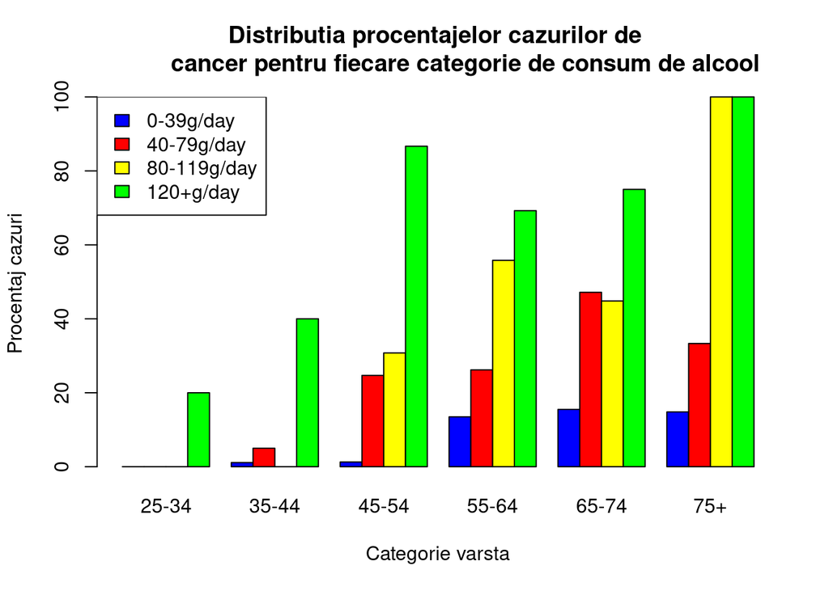

```r
#-------------------------------------------------------------------------------------
alc_t <- cbind("0-39"=procalc1, "40-79"=procalc2, "80-119"=procalc3, "120+"=procalc4)
vect_col5 <- c("blue", "red", "yellow", "green")
barplot(t(alc_t),
        main = "Distributia procentajelor cazurilor de
        cancer pentru fiecare categorie de consum de alcool",
        names.arg = cases_by_age$agegp,
        xlab = "Categorie varsta",
        ylab = "Procentaj cazuri",
        col = vect_col5,
        beside=TRUE,
)
legend("topleft", legend=c("0-39g/day","40-79g/day","80-119g/day", "120+g/day"), fill=vect_col4)
```

In graficul anterior, se pot observa urmatoarele:

- Riscul de cancer creste direct proportional cu varsta
- Riscul de cancer creste direct proportional cu cantitatea de alcool consumata
- Riscul de cancer se tripleaza pentru consumatorii de mai mult de 120 de grame de alcool pe zi pentru categoria de varsta `45-54`
- Consumul moderat de alcool la categoriile de varsta `25-34`, `35-44` are un efect minim asupra riscului de cancer esofagian

## Risk-Calculator

Aplicatia Shiny foloseste functia `probabilitate` pentru estima riscul aparitiei cancerului unui individ conform setului de date, in functie de urmatorul input:

- varsta
- consum alcool zilnic
- consum tutun zilnic

```r
probabilitate <- function (age, alc, tob)
{
  if(age<25)
  {
    stop("Varsta minima este 25")
  }
  if(age>=25&&age<=34)
  {
    vage <- subset(esoph, subset = agegp == "25-34")
  }
  if(age>=35&&age<=44)
  {
    vage <- subset(esoph, subset = agegp == "35-44")
  }
  if(age>=45&&age<=54)
  {
    vage <- subset(esoph, subset = agegp == "45-54")
  }
  if(age>=55&&age<=64)
  {
    vage <- subset(esoph, subset = agegp == "55-64")
  }
  if(age>=65&&age<=74)
  {
    vage <- subset(esoph, subset = agegp == "65-74")
  }
  if(age>=75)
  {
    vage <- subset(esoph, subset = agegp == "75+")
  }


  if(alc<0)
  {
    stop("Cantatitea de alcool nu poate fi negativa")
  }
  if(alc>=0&&alc<=39)
  {
    valc <- subset(vage, subset = alcgp == "0-39g/day")
  }
  if(alc>=40&&alc<=79)
  {
    valc <- subset(vage, subset = alcgp == "40-79")
  }
  if(alc>=80&&alc<=119)
  {
    valc <- subset(vage, subset = alcgp == "80-119")
  }
  if(alc>=120)
  {
    valc <- subset(vage, subset = alcgp == "120+")
  }

  if(tob<0)
  {
    stop("Cantatitea de tutun nu poate fi negativa")
  }
  if(tob>=0&&tob<=0)
  {
    vtob <- subset(valc, subset = tobgp == "0-9g/day")
  }
  if(tob>=10&&tob<=19)
  {
    vtob <- subset(valc, subset = tobgp == "10-19")
  }
  if(tob>=20&&tob<=29)
  {
    vtob <- subset(valc, subset = tobgp == "20-29")
  }
  if(tob>=30)
  {
    vtob <- subset(valc, subset = tobgp == "30+")
  }
  if(length(vtob$ncases)>0)
  {
    controlsage <- sum(vage$ncontrols)
    result <- vtob$ncases*100/controlsage
    return(result)
  }
  else
  {
    warning("Nu exista memorata combinatia de valori")
  }
}
```

este de:

```r
probabilitate(64, 100, 18)
```

```
## [1] 3.305785
```

## Probleme întâlnite:

Pe versiunea de RStudio a colegilor mei (cea de Windows), setul de date `esoph` contine date eronate pentru ultimele intrari (Categoria de varsta 75+). Numarul de ncases>ncontrols (se depisteaza 1 caz din 0 pacienti), lucru care afecteaza procentul cazurilor depistate. Spre exemplu, pt categoria de varsta 75+, exista 8 ncases depistate din 5 ncontrols, deci procentajul de cazuri depistate este 160% (lucru care nu este posibil). Acest lucru afecteaza manipularea si analiza datelor.